# Exploring the BRFSS data

## Setup

### Load packages

```r
library(ggplot2)
library(dplyr)
```

### Load data

```r
load("brfss2013.RData")
```

## Part 1: Data

Scope of Inference:

Important points:

1. The BRFSS conducts telephonic surveys as well as cellphone surveys.
2. The survey is conducted on non-institutionalized adult American population.
3. The people who are surveyed are sampled from the population using **Stratified sampling and Random Sampling**

**Generalizability:** As Random sampling has been used during data collection, the results of any analysis that we perform on this data can be generalized to the Adult American population, that has a telephone or a cellphone, that is not institutionalized.

**Causality:** We cannot arrive at any causal inferences using this data because no random assignment has taken place here.

**Sources of Bias:** This data collection is biased towards households that do no contain any type of telephonic survey in their household. It is also biased towards institutionalized adult population residing in the US.

**Sample Size:** The BRFSS goal is to support at least 4,000 interviews per state each year.

## Part 2: Research questions

**Research quesion 1:**

What effect does lack of exercise have an effect on the BMI (Body Mass Index) of adults in the US? What is the proportion for males as well as females? A BMI greater than 25 is said to be overweight/obese.

Variables of interest:

- X_rfbmi5
- exerany2
- sex

**Research quesion 2:** We are all told that lack of daily exercise leads to obesity and other problems such as high blood cholesterol. Is there a correlation between exercise habits and high blood cholesterol i.e For those who do not exercise, do they have high blood cholesterol ?

Variables of interest:

- exerany2
- toldhi2

**Research quesion 3:**

Regular smoking tobbaco and alcohol consumption is related to the risk of coronary heart disease. What effect does regular consumption of alcohol and tobacco have on the heart? What is the probability that adults who regularly drink and smoke are more prone to coronary heart disease?

Variables of interest:

- X_rfdrhv4
- smokday2
- cvdcrhd4

## Part 3: Exploratory data analysis

**Research quesion 1:**

First we query the required variables into a new dataframe.

```r
males <- brfss2013 %>%
 select(sex,exerany2,X_rfbmi5) %>%
    filter(!is.na(sex),!is.na(exerany2),!is.na(X_rfbmi5),sex=="Male")

summary(males)
```

```
##      sex         exerany2     X_rfbmi5
##  Male  :183825   Yes:137935   No : 51033
##  Female:     0   No : 45890   Yes:132792
```

```r
v1males <- males %>%
 group_by(exerany2) %>%
 summarise(count = n())
v1males
```

```
## # A tibble: 2 x 2
##   exerany2  count
##   <fct>     <int>
## 1 Yes      137935
## 2 No        45890
```

We see that 45890 of the males do not exercise.

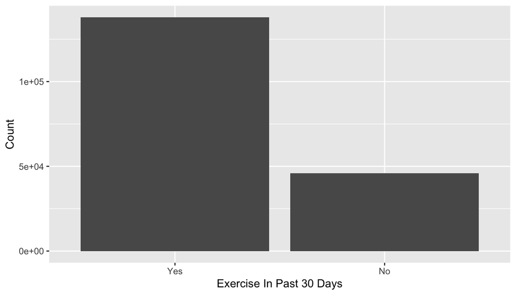

```r
ggplot(data = v1males, aes(exerany2,count)) + geom_bar(stat="identity") + xlab('Exercise In Past 30 Days') + ylab('Count')
```

```r
v2males <- males %>%
  group_by(exerany2,X_rfbmi5) %>%
  summarise(count = n())
probmales <- v2males[4,3] / (v2males[4,3] + v2males[3,3])

probmales * 100
```

```
##      count
## 1 75.37154
```

Approximately 75% of the males who do not exercise have a BMI > 25 (obese / overweight).

Let us see the same statistics in Females

```r
females <- brfss2013 %>%
 filter(!is.na(sex),!is.na(exerany2),!is.na(X_rfbmi5),sex=="Female") %>%
 select(sex,exerany2,X_rfbmi5)

summary(females)
```

```
##      sex         exerany2     X_rfbmi5
##  Male  :     0   Yes:180197   No :101287
##  Female:252172   No : 71975   Yes:150885
```

```r
v1females <- females %>%
 group_by(exerany2) %>%
 summarise(count = n())
v1females
```

```
## # A tibble: 2 x 2
##   exerany2  count
##   <fct>     <int>
## 1 Yes      180197
## 2 No        71975
```

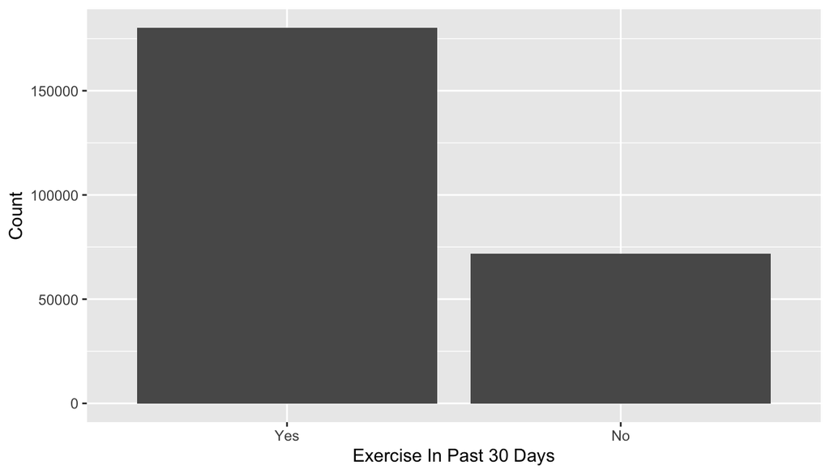

```r
ggplot(data = v1females, aes(exerany2,count)) + geom_bar(stat="identity") + xlab('Exercise In Past 30 Days') + ylab('Count')
```

```r
v2females <- females %>%
  group_by(exerany2,X_rfbmi5) %>%
  summarise(count = n())
probfemales <- v2females[4,3] / (v2females[4,3] + v2females[3,3])
probfemales * 100
```

```
##      count
## 1 69.00729
```

Approximately 69% of Females who do not exercise have a BMI > 25.

**Research quesion 2:**

```r
sub <- brfss2013 %>%
     select(toldhi2,exerany2) %>%
                filter(!is.na(toldhi2),!is.na(exerany2))

summary(sub)
```

```
##  toldhi2      exerany2
##  Yes:172830   Yes:287090
##  No :220092   No :105832
```

```r
var1 <- sub %>%
 filter(exerany2=="No") %>%
 group_by(toldhi2) %>%
 summarise(cnt = n())
var1
```

```
## # A tibble: 2 x 2
##   toldhi2   cnt
##   <fct>   <int>
## 1 Yes     53352
## 2 No      52480
```

Let us visualize this

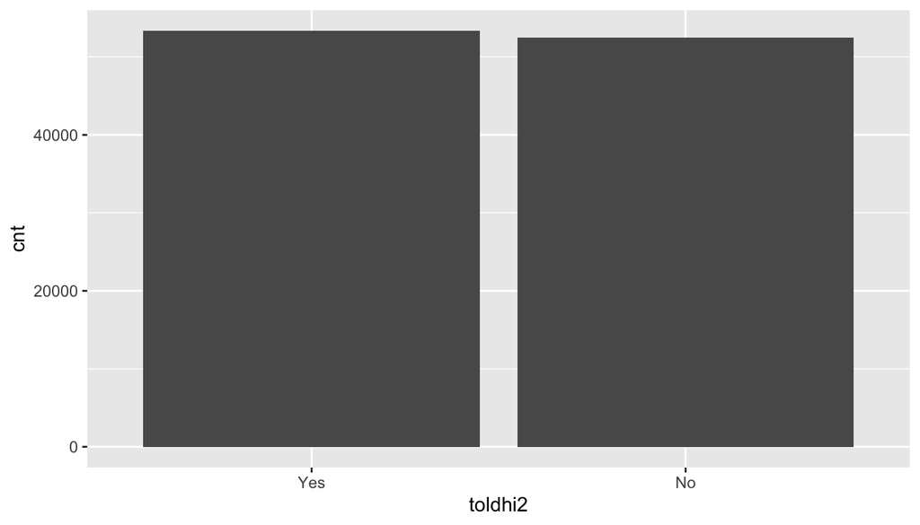

```r
ggplot(data = var1, aes(toldhi2,cnt)) + geom_bar(stat="identity")
```

**From the bar plot above we can see that adults who do not exercise may or may not have high blood cholesterol. Hence there is no conclusive evidence that lack of exercise may lead to high blood cholesterol.**

**Research quesion 3:**

```r
df <- brfss2013 %>%
    select(smokday2,X_rfdrhv4,cvdcrhd4) %>%
    filter(!is.na(smokday2),!is.na(X_rfdrhv4),!is.na(cvdcrhd4))

summary(df)
```

```
##        smokday2      X_rfdrhv4    cvdcrhd4
##  Every day : 52812   No :189744   Yes: 17067
##  Some days : 20574   Yes: 16996   No :189673
##  Not at all:133354
```

First we remove all the NA values.

```r
smevents <- df %>%
 filter(smokday2 == "Every day" | smokday2 == "Some days" & X_rfdrhv4 == "Yes" & cvdcrhd4 == "Yes")%>%
 summarise(cnt = n())
```

```r
allevents <- df %>%
 summarise(cnt = n())

allevents
```

```
##      cnt
## 1 206740
```

```r
prob <- smevents / allevents * 100
prob
```

```
##        cnt
## 1 25.56738
```

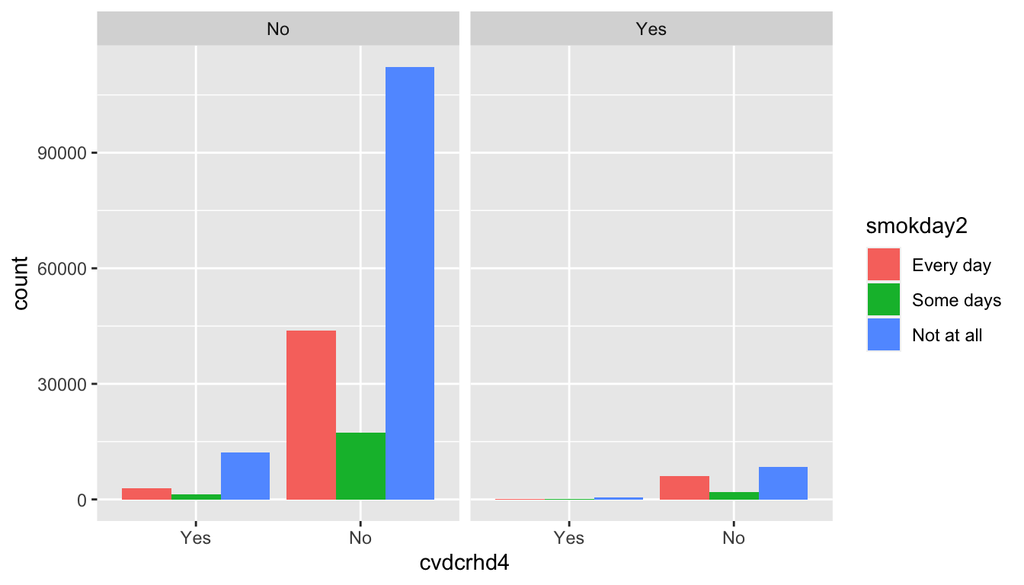

```r
 ggplot(df, aes(x=cvdcrhd4, fill = smokday2)) +
   geom_bar(position="dodge") + facet_wrap( ~ X_rfdrhv4, ncol=2)
```